# Reporting

> From the analysis of the twitter data-frame that consists of the twitter archive dataframe, image predictor data-frame and the tweet_json data frame merged together, the insights I discovered are communicated below.

> Firstly, i discovered, using a scatterplot, that the retweet and favorite counts were positively correlated, so the retweet count increased as the favorite count increased. Also, using a histogram, I noticed that the favorite count was greater than the retweet count. Therefore, one can imply from the data, that tweets on the @dog_rates twitter page are more likely to be favorited than they are to be retweeted.

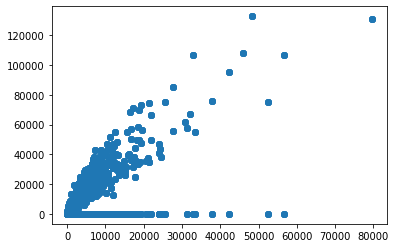

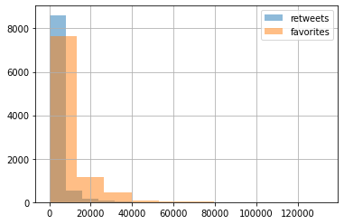

> Fom the scatterplot above, the positive correlation is glaring and the histogram clearly shows the extent of the distribution of the favorite and retweet counts.

> For my Second visualization, I used a bar chart to show the most used source for interaction by the @dog_rates user. It was very obvious what the answer to this question was, after the barchat was plotted and displayed. The most used source for interaction by the @dog_rates user is his mobile phone, precisely his iphone. This realization follows societal norms as social media activities are mostly done on mobile phones. From the insight gotten from the barchart, one may imply that most of the tweets are done single-handedly and not as a group or company and by a sole user.

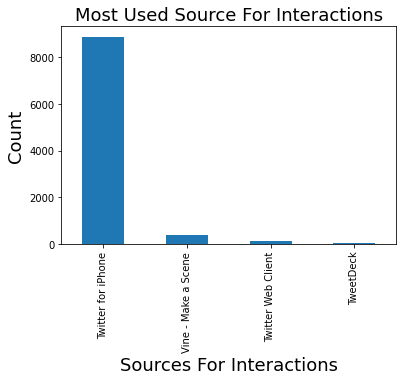

> Finally, I also used a bar chart to show which dog slang name is the most commonly used. From the bar chart, it was evident that puppers were the most common dogs among the others that were posted on the @dog_rates twitter page. Pupper is the name given to puppies basically, and from the popularity of this slang name on the @dog_rates twitter page, one can imply that the owner of this page has a liking to puppies. They are cute aren't they?

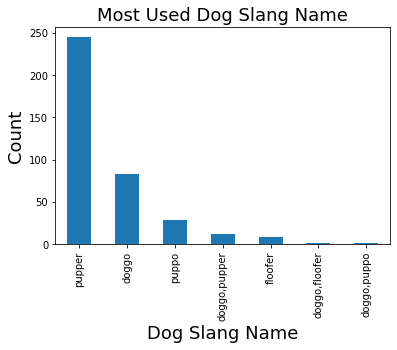

> I also added a wordcloud, using the text columnn of the combined data-frame, to further describe what the tweets on this page contain. It's mainly for people who are not familiar with the page, so as to get an idea of what to expect.

[figure not shown]

> For wordclouds, the size of a displayed word determines its importance. In this wordcloud above, the word pup is very noticeable and can surely give away an idea of what this data-frame is about, dogs. This wordcloud also shows that the word pup comes up a lot, therefore reinforcing the realization about puppers being the most common used slangs, as puppers are in fact adorable little puppies.